# Automatic Registration and Convex Clustering of Time Series

*ICASSP 2021: Proceedings of the 2021 IEEE International Conference on Acoustics, Speech and Signal Processing*, pp.5609-5613. 2021

Michael Weylandt https://michaelweylandt.github.io (UF Informatics Insitute) , George Michailidis (Department of Statistics and Informatics Institute, University of Florida)  
02-15-2022

**Abstract:** Clustering of time series data exhibits a number of challenges not present in other settings, notably the problem of registration (alignment) of observed signals. Typical approaches include pre-registration to a user-specified template or time warping approaches which attempt to optimally align series with a minimum of distortion. For many signals obtained from recording or sensing devices, these methods may be unsuitable as a template signal is not available for pre-registration, while the distortion of warping approaches may obscure meaningful temporal information. We propose a new method for automatic time series alignment within a *clustering problem*. Our approach, Temporal Registration using Optimal Unitary Transformations (TROUT), is based on a novel dissimilarity measure between time series that is easy to compute and automatically identifies optimal alignment between pairs of time series. By embedding our new measure in a optimization formulation, we retain well-known advantages of computational and statistical performance. We provide an efficient algorithm for TROUT-based clustering and demonstrate its superior performance over a range of competitors.

**Publisher DOI:** 10.1109/ICASSP39728.2021.9414417

**Working Copy:** ArXiv 2012.04756

**Summary:** Clustering time series is a common problem in many applications, but it is much more difficult when analyzing non-aligned signals. Typically, signals are pre-registered to some template or common alignment, but this assumes that such a template exists, when discovering “standard signals” is often the goal of clustering in the first case. We instead propose to align signals *to each other* **within** the clustering problem. Given two signals, the optimal alignment between them can be found by an orthogonal rotation (phase-shift), with closed form: this motivates TROUT-clustering
$$\text{argmin}_{\mathbf{U} \in \mathbb{C}^{n \times p}} \frac{1}{2}d_{\text{TROUT}}(\mathbf{U}, \mathbf{X})^2 + \lambda \sum_{\substack{i, j = 1 \\ i < j}}^n w_{ij} \|\mathbf{U}_{i\cdot} - \mathbf{U}_{j\cdot}\|_q$$
where
$$d_{\text{TROUT}}(\mathbf{u}, \mathbf{x}) = \min_{\theta \in [0, 2\pi)} \|\mathbf{u} - e^{i \theta} \mathbf{x}\|_2 \implies d_{\text{TROUT}}(\mathbf{U}, \mathbf{X})^2 = \sum_{i=1}^n d_{\text{TROUT}}(\mathbf{U}_{i\cdot}, \mathbf{X}_{i\cdot})^2.$$
is $d_{\text{TROUT}}$ our “phase-adaptive” (optimally aligning) distance[^1] To solve this problem, we develop a Majorization-Minimization scheme, the sub-problems of which have closed form solution, yielding an efficient algorithm.

Note that the clustering formulation is designed so that each observation (row of $\mathbf{X}$) is rotated to coincide with the shared centroids (row of $\mathbf{U}$) rather than to each other: this avoids the registration problem entirely, but does give a solution that is only identified up to phase. Our method performs well under a variety of noise conditions and often even out-performs traditional clustering methods with oracle pre-registration.

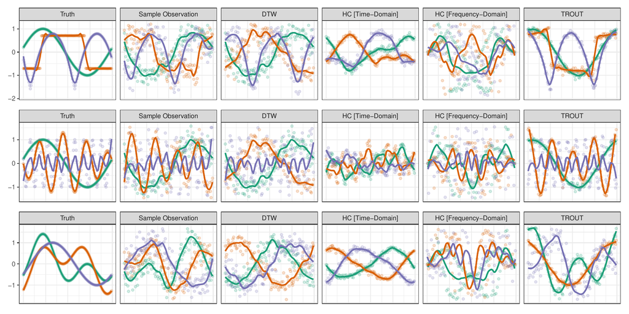

Examples of TROUT Clustering

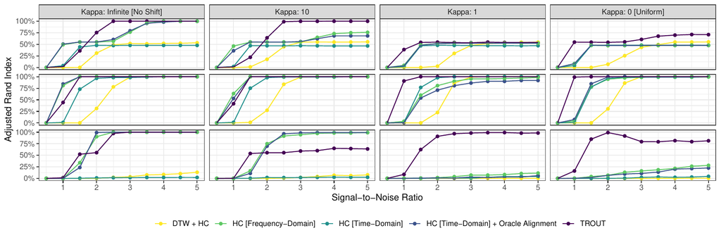

Comparison of TROUT, Time-Warping, and Traditional Clustering

**Citation:**

```
@INPROCEEDINGS{Weylandt:2021-TROUT,
  AUTHOR="Michael Weylandt and George Michailidis",
  TITLE="Automatic Registration and Convex Clustering of Time Series",
  DOI="10.1109/ICASSP39728.2021.9414417"
  PAGES={5609-5613},
  CROSSREF="ICASSP:2021"
}

@PROCEEDINGS{ICASSP:2021,
  BOOKTITLE="ICASSP 2021: Proceedings of the 2021 IEEE International Conference on Acoustics, Speech and Signal Processing",
  YEAR=2021,
  LOCATION="Toronto, Canada"
  EDITOR="Tim Davidson and Dong Yu"
}
```

[^1]: $d_{\text{TROUT}}$ does not define a true metric, so the TROUT-clustering problem is not guaranteed to be convex.